# Statistical Inference - Peer Grading

Nikhil Chandra

October 2, 2018

## Effectiveness of Vitamin C on Tooth Growth in Guinea Pigs

## Overview

In this project, we are going to analyze the ToothGrowth data in the dataset .

```
    1. We are going to load the ToothGrowth data and do some basic exploratory data analysis.
    2. Then we will provide a summary for the data.
    3. Usage of hypothesis or confidence intervals tests to compare tooth growth by supplement and dose.
    4. Provide assumptions and the Conclusion.
```

```r
        library(dplyr)
```

```r
        library(ggplot2)
        library(datasets)
        library(gridExtra)
        library(GGally)
```

## 1. Load the ToothGrowth data - Perform basic Analysis.

### Load dataset - ToothGrowth

```r
        data(ToothGrowth)
        # to keep  naming format with lowercase 1st letter and uppercase subsequent letters.
        toothGrowth <- ToothGrowth
        # convert to factor for plotting
        toothGrowth$dose <- as.factor(toothGrowth$dose)
```

### Some Exploratory Analysis.

```r
        str(toothGrowth)
```

```
## 'data.frame':    60 obs. of  3 variables:
##  $ len : num  4.2 11.5 7.3 5.8 6.4 10 11.2 11.2 5.2 7 ...
##  $ supp: Factor w/ 2 levels "OJ","VC": 2 2 2 2 2 2 2 2 2 2 ...
##  $ dose: Factor w/ 3 levels "0.5","1","2": 1 1 1 1 1 1 1 1 1 1 ...
```

```r
        head(toothGrowth)
```

|  | len | supp | dose |
| --- | --- | --- | --- |
| 1 | 4.2 | VC | 0.5 |
| 2 | 11.5 | VC | 0.5 |
| 3 | 7.3 | VC | 0.5 |
| 4 | 5.8 | VC | 0.5 |
| 5 | 6.4 | VC | 0.5 |
| 6 | 10.0 | VC | 0.5 |

```r
        tail(toothGrowth)
```

|  | len | supp | dose |
| --- | --- | --- | --- |
| 55 | 24.8 | OJ | 2 |
| 56 | 30.9 | OJ | 2 |
| 57 | 26.4 | OJ | 2 |
| 58 | 27.3 | OJ | 2 |
| 59 | 29.4 | OJ | 2 |
| 60 | 23.0 | OJ | 2 |

```r
        summary(toothGrowth)
```

```
##       len        supp     dose
##  Min.   : 4.20   OJ:30   0.5:20
##  1st Qu.:13.07   VC:30   1  :20
##  Median :19.25           2  :20
##  Mean   :18.81
##  3rd Qu.:25.27
##  Max.   :33.90
```

### Number of Rows and Columns.

```r
        dim(toothGrowth)
```

```
## [1] 60  3
```

### Sample Size n

```r
        sample_size <- length(toothGrowth$len)
        sample_size
```

```
## [1] 60
```

### Mean group by dose

```r
        ## X bar - Mean
        mean_groups <- aggregate(toothGrowth$len,list(toothGrowth$supp,toothGrowth$dose),mean)
        mean_groups
```

| Group.1 | Group.2 | x |
| --- | --- | --- |
| OJ | 0.5 | 13.23 |
| VC | 0.5 | 7.98 |
| OJ | 1 | 22.70 |
| VC | 1 | 16.77 |
| OJ | 2 | 26.06 |
| VC | 2 | 26.14 |

### Standard Deviation - group by dose

```r
        ## s - standard Deviation
        sd_group <- aggregate(toothGrowth$len,list(toothGrowth$supp,toothGrowth$dose),sd)
        sd_group
```

| Group.1 | Group.2 | x |
| --- | --- | --- |
| OJ | 0.5 | 4.459709 |
| VC | 0.5 | 2.746634 |
| OJ | 1 | 3.910953 |
| VC | 1 | 2.515309 |
| OJ | 2 | 2.655058 |
| VC | 2 | 4.797731 |

# 2. Summary of the data.

```r
        summary(toothGrowth)
```

```
##       len        supp     dose
##  Min.   : 4.20   OJ:30   0.5:20
##  1st Qu.:13.07   VC:30   1  :20
##  Median :19.25           2  :20
##  Mean   :18.81
##  3rd Qu.:25.27
##  Max.   :33.90
```

### Table

```r
        table(toothGrowth$supp, toothGrowth$dose)
```

```
##
##      0.5  1  2
##   OJ  10 10 10
##   VC  10 10 10
```

### Plots

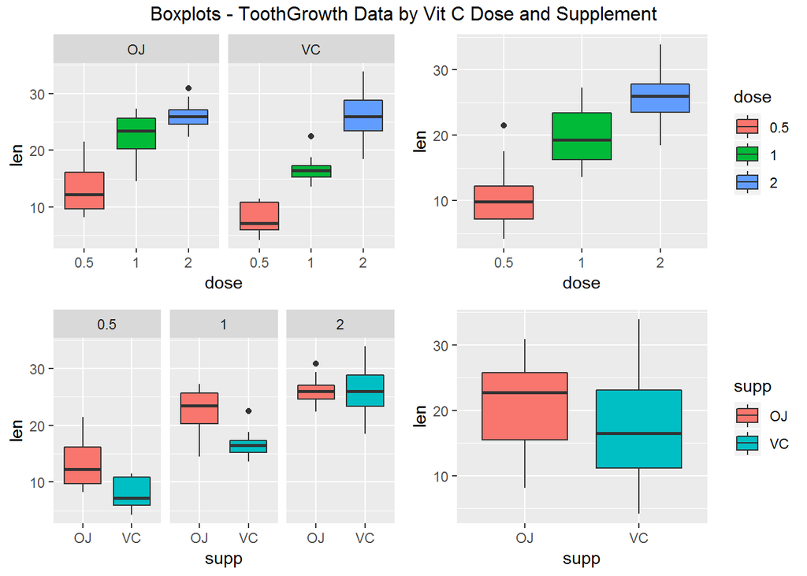

# 3. Usage of hypothesis or confidence intervals tests to compare tooth growth by supplement and dose.

Perform - Analysis of Variance

```r
anova.out <- aov(len ~ supp * dose, data=toothGrowth)
summary(anova.out)
```

```
##             Df Sum Sq Mean Sq F value   Pr(>F)
## supp         1  205.4   205.4  15.572 0.000231 ***
## dose         2 2426.4  1213.2  92.000  < 2e-16 ***
## supp:dose    2  108.3    54.2   4.107 0.021860 *
## Residuals   54  712.1    13.2
## ---
## Signif. codes:  0 '***' 0.001 '**' 0.01 '*' 0.05 '.' 0.1 ' ' 1
```

```r
TukeyHSD(anova.out)
```

```
##   Tukey multiple comparisons of means
##     95% family-wise confidence level
##
## Fit: aov(formula = len ~ supp * dose, data = toothGrowth)
##
## $supp
##       diff       lwr       upr     p adj
## VC-OJ -3.7 -5.579828 -1.820172 0.0002312
##
## $dose
##         diff       lwr       upr   p adj
## 1-0.5  9.130  6.362488 11.897512 0.0e+00
## 2-0.5 15.495 12.727488 18.262512 0.0e+00
## 2-1    6.365  3.597488  9.132512 2.7e-06
##
## $`supp:dose`
##                diff        lwr        upr     p adj
## VC:0.5-OJ:0.5 -5.25 -10.048124 -0.4518762 0.0242521
## OJ:1-OJ:0.5    9.47   4.671876 14.2681238 0.0000046
## VC:1-OJ:0.5    3.54  -1.258124  8.3381238 0.2640208
## OJ:2-OJ:0.5   12.83   8.031876 17.6281238 0.0000000
## VC:2-OJ:0.5   12.91   8.111876 17.7081238 0.0000000
## OJ:1-VC:0.5   14.72   9.921876 19.5181238 0.0000000
## VC:1-VC:0.5    8.79   3.991876 13.5881238 0.0000210
## OJ:2-VC:0.5   18.08  13.281876 22.8781238 0.0000000
## VC:2-VC:0.5   18.16  13.361876 22.9581238 0.0000000
## VC:1-OJ:1     -5.93 -10.728124 -1.1318762 0.0073930
## OJ:2-OJ:1      3.36  -1.438124  8.1581238 0.3187361
## VC:2-OJ:1      3.44  -1.358124  8.2381238 0.2936430
## OJ:2-VC:1      9.29   4.491876 14.0881238 0.0000069
## VC:2-VC:1      9.37   4.571876 14.1681238 0.0000058
## VC:2-OJ:2      0.08  -4.718124  4.8781238 1.0000000
```

```r
confint(anova.out)
```

```
##                   2.5 %    97.5 %
## (Intercept)  10.9276907 15.532309
## suppVC       -8.5059571 -1.994043
## dose1         6.2140429 12.725957
## dose2         9.5740429 16.085957
## suppVC:dose1 -5.2846186  3.924619
## suppVC:dose2  0.7253814  9.934619
```

```r
print(model.tables(anova.out,"means"),digits=3)
```

```
## Tables of means
## Grand mean
##
## 18.81333
##
##  supp
## supp
##    OJ    VC
## 20.66 16.96
##
##  dose
## dose
##   0.5     1     2
## 10.60 19.73 26.10
##
##  supp:dose
##     dose
## supp 0.5   1     2
##   OJ 13.23 22.70 26.06
##   VC  7.98 16.77 26.14
```

The Analysis of the Tukey HSD analysis shows some significant differences between each of the groups in supp and dose.

# 4. Assumptions and Conclusion.

#### With the above data we can conclude that the data indicates that both the dosage and supplement have effects on the length growth of teeth of guinea pig .

Supplement type has also shown influence. OJ has a greater average teeth growth with the combination of dosages at 0.5 and 1 than for the VC supplement. But, at dose level 2, there seems to be no major significant effect (similar means and confidence intervals) between the VC supplement and the OJ.

The above conclusions are based on the following assumptions:

1. The distribution of the means is approximately normal.
2. Dosage and supplement are randomly assigned.